# La Política de la Corrupción

Sesión 1: Bienvenida, y ¿qué es la corrupción?

Bogdan G. Popescu

bgpopescu@tec.mx

Tecnológico de Monterrey

# El curso

## Qué vas a poder hacer

- Distinguir soborno, fraude, clientelismo, patronazgo y captura del Estado
- Explicar por qué la corrupción persiste en algunos países
- Sopesar lo que dice la evidencia sobre cuánto cuesta la corrupción
- Comparar cómo algunos países redujeron la corrupción, y por qué
- Leer un estudio y decir qué estableció realmente

## Logística

- **Sesiones**: clase los **lunes** · discusión y presentaciones los **jueves**
- **Periodo**: 10 de ago – 4 de dic de 2026 · sin clase en Semana Tec (14–18 de sep, 26–30 de oct) ni el Día de la Revolución (lun 16 de nov)
- **Asesorías**: con cita previa — bgpopescu@tec.mx
- **Materiales**: sitio del curso, una página por sesión — diapositivas y lecturas (PDF)
- **Lecturas**: **Obligatorias** = antes de clase, evaluables · **Recomendadas** = para profundizar. Ambas se usan para las presentaciones
- **Exámenes**: parcial **jue 24 de sep** · final **jue 3 de dic** — en clase, sin materiales de consulta

## Evaluación y reglas

| Componente | Peso |
| --- | --- |
| Contribuciones | **33%** |
| Examen parcial | **33%** |
| Examen final | **33%** |

**Contribuciones** — el promedio de:

- **Presentación** — una exposición de 10 minutos sobre una lectura asignada
- **Asistencia** — presencia a lo largo del semestre
- **Participación** — lo que aportas a la discusión
- **Preguntas** — dos por sesión, antes de las 11 p.m. del miércoles
- **Calidad de las preguntas** — se juzga el fondo, no la entrega

## Preguntas en cada sesión

Entrega **dos preguntas** sobre las lecturas de la sesión antes de las **11 p.m. del miércoles**, previo a la discusión del jueves. Sirven para guiarla.

Cada pregunta debe tener entre 50 y 100 palabras.

Empieza haciendo referencia a una parte específica del texto o a su argumento central. Luego formula una pregunta crítica que abra la discusión, no que evalúe la memoria.

Las preguntas se califican por su calidad, no solo por entregarlas.

## Ejemplo de pregunta

**Nota**

Nye sostiene que la corrupción a veces puede ayudar a un país pobre a desarrollarse, porque los sobornos permiten sortear trámites lentos y por fin avanzar. Pero si los sobornos son lo que vuelve rentables esos trámites lentos, ¿por qué un funcionario los simplificaría? Quien gana con la demora tiene motivos para crear más demora. Nye trata la burocracia lenta como un obstáculo fijo del que la corrupción permite escapar. ¿Y si la corrupción es lo que produce esa lentitud? ¿Cómo distinguiríamos una cosa de la otra?

**¿Por qué es buena?**

- 50–100 palabras
- Señala una afirmación concreta, no “la lectura” en general
- Pregunta en vez de resumir
- Ofrece una explicación rival: la corrupción quizá causa los trámites lentos, no los remedia

## Presentaciones

- **Una por estudiante**: sobre una **lectura** asignada, un **jueves** — a partir del **20 de ago**, dos o tres de ustedes cada semana
- **Formato**: 10 minutos
- **Estructura**: introducción clara, puntos principales, conclusión
- **Análisis crítico**: ve más allá del resumen — qué no aborda el autor, los límites de la evidencia, explicaciones rivales
- **Cierra con un veredicto**: bien sustentado · plausible pero no establecido · no establecido por estos datos
- **Apoyos visuales**: texto legible, imágenes pertinentes, diapositivas sin saturar
- **Preparación**: ensaya para respetar el tiempo; no leas literalmente de las diapositivas ni de tus notas
- **Participa**: prepárate para 2–3 preguntas de tus compañeros o del profesor

## Cómo se califican las presentaciones

| Criterio | Puntos |
| --- | --- |
| **Análisis crítico y veredicto** — la premisa no dicha, las explicaciones rivales, un veredicto defendible | 30 |
| **Dominio del contenido** — la afirmación que importa y la evidencia que la sostiene | 20 |
| **Selección y enfoque** — una línea de argumento, desarrollada, dentro del tiempo | 15 |
| **Organización** — introducción, puntos principales, conclusión | 15 |
| **Claridad de expresión** | 10 |
| **Participación y respuesta** — hablarle al salón, responder preguntas | 10 |

El análisis pesa más que la cobertura. En diez minutos, **elegir bien es la habilidad**.

# Parte I: El enigma — cuatro casos

## El juego de hoy: “¿Esto es corrupción?”

Cuatro situaciones reales — tres de América Latina, una de Estados Unidos.

Para cada una vas a votar:

- **Claramente corrupto**
- **No es corrupto**
- **Es complicado**

Anota tus cuatro votos — volveremos a ellos al final.

## Caso 1 — Una parada policial en la calle

México

- Un conductor se pasa un alto en la ciudad
- La multa oficial: dinero, puntos, una mañana perdida
- El oficial insinúa: *“Podemos arreglarlo aquí”*
- Cambian de manos doscientos pesos; sin infracción, sin registro
- Los dos salen ganando — hoy

¿Corrupción? ¿Quién es exactamente la víctima?

[figure not shown]

Oficial de tránsito deteniendo un auto, Ciudad de México

Foto: ProtoplasmaKid, Wikimedia Commons, CC BY-SA 4.0.

## Caso 2 — Despensas antes de la elección

México

- Semana electoral, una colonia de bajos ingresos
- Operadores del partido reparten despensas y tarjetas de tienda
- Se anotan los nombres; se insinúa que los beneficios dependen de ganar
- 2012: las *acusaciones* de las “tarjetas Soriana” — nunca probadas en tribunales
- Nadie fue coaccionado; las campañas regalan cosas en todas partes

¿Corrupción? ¿Un regalo, un pago o una compra?

## Caso 3 — La puerta giratoria

Estados Unidos

- Un regulador financiero supervisa un banco importante durante años
- Poco después de dejar el cargo, es contratado por ese banco — al triple del sueldo
- Totalmente legal tras un breve periodo de espera obligatorio
- Los conocimientos deberían poder emplearse; ¿quién más conoce tan bien las reglas?
- Pero: ¿la *expectativa* del empleo suavizó la supervisión antes?

¿Corrupción? Nunca se intercambió nada — quizá.

## Caso 4 — La Estafa Maestra

México

- 2013–2014: once dependencias del gobierno mexicano adjudicaron contratos a ocho universidades públicas
- Las universidades debían ejecutar proyectos públicos
  - en su lugar subcontrataron la mayor parte del trabajo a empresas privadas
  - De las 186 empresas contratadas, 128 eran fantasma, irregulares o imposibles de localizar
- Periodistas rastrearon 7,670 millones de pesos de dinero público desviado

¿Corrupción? Aquí casi nadie duda. ¿Por qué?

Fuente: Animal Político y Mexicanos Contra la Corrupción y la Impunidad (2017).

## Ejercicio 1 — Vota y defiende

≈ 5 minutos

**Consigna.** En parejas: ordenen los cuatro casos de *más claramente corrupto* a *menos claramente corrupto*.

1. Comparen sus votos en los cuatro casos.
2. ¿Por qué es corrupto, o por qué no?

Tengan a la vista su criterio — está por ponerse a prueba.

## Los cuatro casos, lado a lado

|  | Caso | Dónde | En una línea |
| --- | --- | --- | --- |
| **1** | Una parada policial en la calle | México | alto · 200 pesos · sin infracción, sin registro |
| **2** | Despensas antes de la elección | México | semana electoral · despensas y tarjetas · nombres anotados |
| **3** | La puerta giratoria | Estados Unidos | el regulador supervisa un banco · el banco lo contrata |
| **4** | La Estafa Maestra | México | contratos vía universidades públicas · empresas fantasma · 7,670 millones |

Ordénenlos. Escriban su criterio en una sola frase.

## ¿Qué reveló nuestro desacuerdo?

Digan en voz alta el criterio de su pareja — los juntamos.

Criterios que suelen aparecer, y dónde chocan:

- **Legalidad** — algunos casos eran ilegales pero pequeños; otros, legales pero enormes
- **Daño** — difuso en unos casos, brutal en otros
- **Intención** — algunos actores creían estar haciendo su trabajo

**¿Y qué?** La intuición sola no puede trazar la línea. No hay una forma neutral de contar la corrupción: antes de medirla, perseguirla o reformarla, hay que decidir qué cuenta como corrupción.

# Parte II: Definir la corrupción

## Cómo abordan la corrupción tres instituciones

| Institución | Cómo enmarca la corrupción | Dónde traza la línea |
| --- | --- | --- |
| Banco Mundial (1997) | el abuso del cargo público para beneficio privado | el sector público |
| Transparencia Internacional | el abuso del poder encomendado para beneficio privado | poder público **y** privado |
| OCDE (2008) | sin definición única; especifica actos delictivos — soborno de funcionarios, tráfico de influencias | delitos perseguibles |

- Las tres vienen de instituciones de *reforma* — hechas para medir y perseguir, no para zanjar qué *es* la corrupción

Fuentes: Banco Mundial (1997); Transparencia Internacional (2025); OCDE (2008). Formulaciones traducidas del original en inglés.

## Prueba de fuego — la puerta giratoria

Volvamos al **Caso 3**: el regulador supervisa un banco y luego el banco lo contrata.

¿Hubo corrupción?

- **Banco Mundial** — solo si abusó del cargo público *mientras seguía en el gobierno*
- **Transparencia Internacional** — solo si abusó del poder que se le encomendó
- **OCDE** — aceptar el empleo no es, en sí mismo, un delito de soborno

Los mismos hechos. Ninguna definición da un sí o un no limpio.

## Tres preguntas para cualquier caso

Cuando creas que algo puede ser corrupto, pregunta:

[figure not shown]

- **Caso 1, la parada de tránsito:** autoridad policial → la infracción nunca se levanta → 200 pesos al oficial
- Los nombres técnicos de esas tres: **poder encomendado** → **desviación del deber** → **beneficio privado**
- Casi todas las definiciones lidian con los mismos tres problemas — pero discrepan sobre qué cuenta como poder, mal uso y beneficio
- La más difícil es la de en medio: **¿con qué criterio decimos que el poder se usó *mal*?**

## Tres formas de definir la corrupción

Tres respuestas académicas a esa pregunta de en medio — **¿mal usado según qué criterio?**

| Enfoque | La conducta es corrupta cuando viola… | Ejemplo |
| --- | --- | --- |
| **Cargo público** | los deberes formales de un funcionario público | Nye (1967) |
| **Interés público** | los intereses más amplios de la sociedad | Friedrich |
| **Opinión pública** | lo que la ciudadanía suele considerar corrupto | enfoques basados en encuestas |

Pero cada criterio crea un problema:

- **Cargo público:** ¿y si las reglas mismas son corruptas?
- **Interés público:** ¿quién decide qué cuenta como “interés público”?
- **Opinión pública:** ¿y si la ciudadanía no se pone de acuerdo?

Clasificación siguiendo a Heidenheimer (1970).

## La definición de Nye: el cargo público

**Nye (1967):** la corrupción es una **desviación de los deberes formales de un cargo público** en busca de un **beneficio privado**.

- **Fortaleza:** clara y observable — se puede verificar el deber, y verificar el beneficio
- **Problema:** ¿y si la influencia dañina es totalmente legal?

### ¿Y si las reglas mismas permiten el favoritismo?

**Legal ≠ necesariamente honesto**

El cabildeo, el patronazgo, el acceso preferente o los conflictos de interés pueden influir en decisiones públicas **sin violar deberes formales**.

## Cambia la medida, cambia el retrato

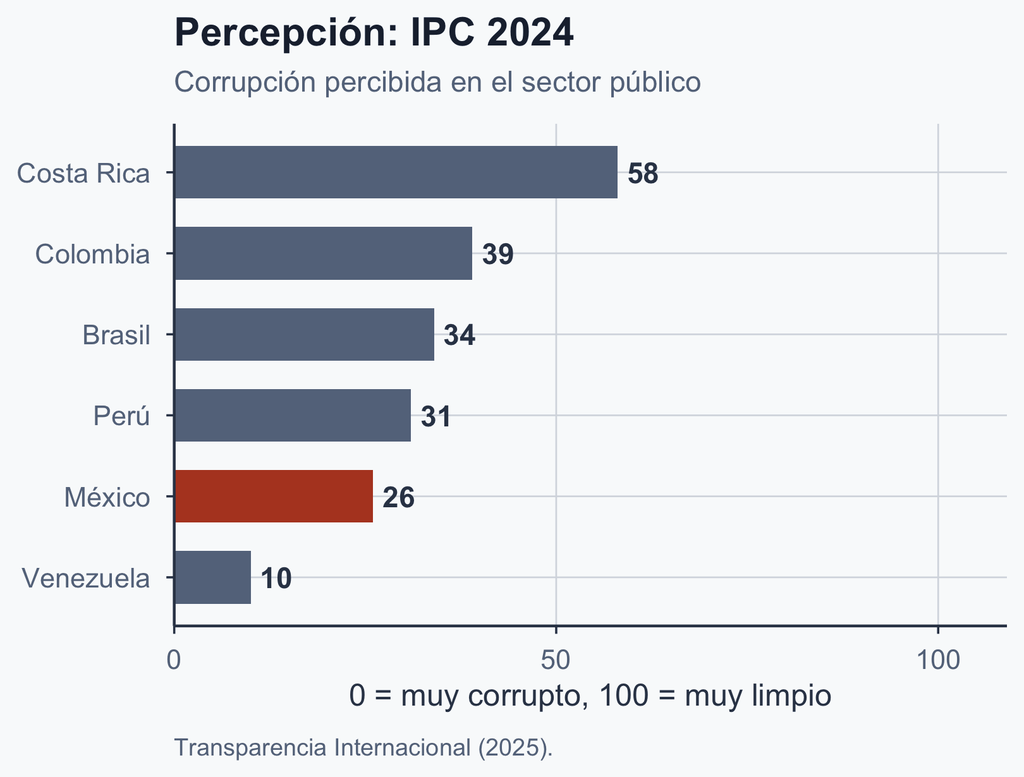

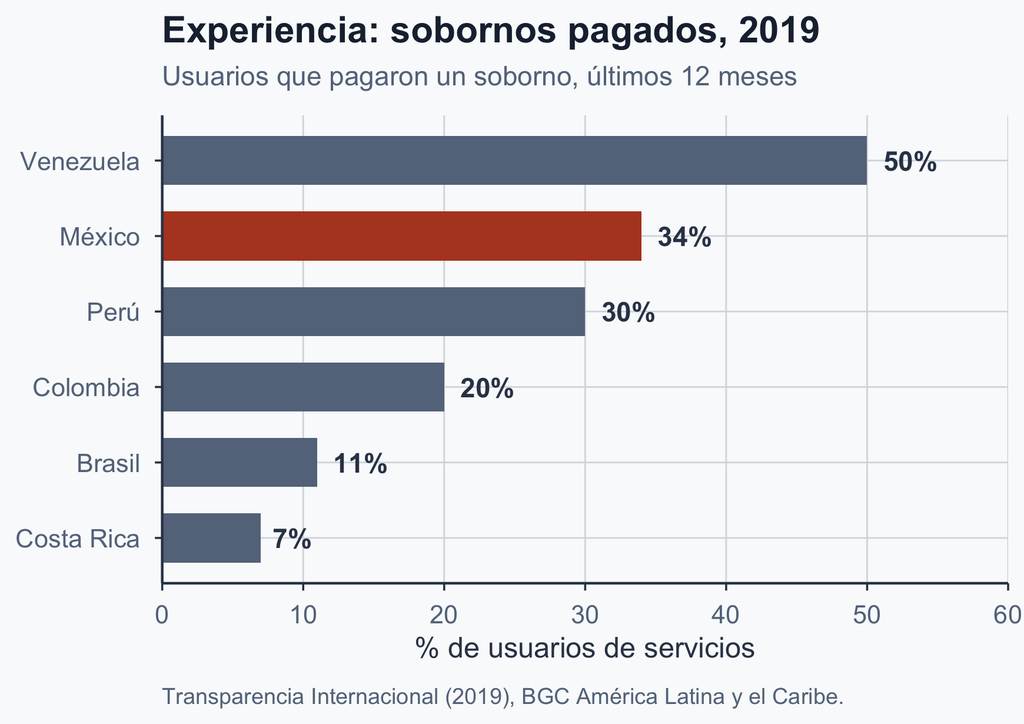

**¿Y qué?** 26/100 en percepción, 34% en experiencia — no se contradicen, miden cosas distintas. “Corrupción” es un paraguas: ahora vamos a nombrar sus partes.

# Parte III: Un vocabulario de actos corruptos

## El mapa del terreno: ¿qué hace el actor?

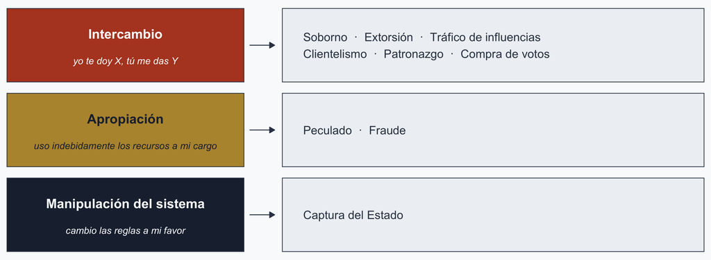

- Son **mecanismos, no cajas mutuamente excluyentes** — un mismo escándalo puede combinar varios

Ilustración del autor. Los términos son estándar en la literatura; la agrupación por mecanismo es del autor.

## Intercambio: qué se da y qué se obtiene

**A cambio de una decisión**

- **Soborno**: una recompensa para torcer el juicio de quien tiene un encargo
- **Extorsión**: pago arrancado por **coacción** — amenazas, no ofertas
- **Tráfico de influencias**: vender *acceso* a quien decide (CNUCC, art. 18)

**A cambio de apoyo político**

- **Clientelismo**: beneficios por apoyo, de forma continua, condicionada y vigilada
- **Patronazgo**: *empleos* públicos como moneda de lealtad
- **Compra de votos**: una compra puntual en tiempos electorales

**La pregunta clave: ¿cuál es el intercambio?**

- **Cabildeo**: busca influir en una decisión mediante gestión permitida
- **Tráfico de influencias**: vende acceso o influencia *indebida* — la frontera con el cabildeo es disputada, no idéntica
- Caso 1 — la mordida: ¿fue **ofrecida, exigida o coaccionada**?
- Caso 2 — las despensas: ¿el beneficio estaba **condicionado** a cómo votaras?

## Apropiación: peculado y fraude

- **Peculado**: desviar recursos que se te encomendó administrar
- **Fraude**: engaño — empresas fantasma, facturas falsas, aviadores
- Muchas veces no hay víctima en el momento, así que no hay denuncias — detectarlo exige **auditorías**
- Pero el fraude también puede ser colusivo: los licitantes falsos son un *intercambio*
- La Estafa Maestra combinó desvío, engaño y colusión

[figure not shown]

“¿Quién se robó el dinero del pueblo?” — cada quien señala a otro

Thomas Nast, Harper’s Weekly, 1871. Wikimedia Commons, dominio público.

## Manipulación del sistema: captura del Estado

- Empresas o élites moldean **las reglas mismas**, no su aplicación
- Leyes, decretos, doctrina judicial — escritos a la medida (Hellman, Jones y Kaufmann, 2003)
- El soborno ordinario dobla las reglas existentes; la captura las *reescribe*
- Una vez que la captura triunfa, la conducta que protege se vuelve **legal**
- **Un ejemplo limpio:** una asociación de refresqueras redacta las reglas del impuesto al azúcar; el congreso las adopta textualmente

No hace falta ningún soborno. La regla misma es el premio.

## Los cuatro casos, clasificados

Diapositiva de síntesis — nuestro vocabulario aplicado:

| Caso | Mejor etiqueta | ¿Ilegal? | ¿Se abusó del poder encomendado? |
| --- | --- | --- | --- |
| 1. Parada policial | soborno menor / extorsión | sí | sí — discrecionalidad policial |
| 2. Despensas | compra de votos / clientelismo | la práctica: sí; el caso de 2012: acusación | sí — vía la maquinaria partidista |
| 3. Puerta giratoria | tráfico de influencias | no | anticipado, no probado |
| 4. Estafa Maestra | peculado + fraude | sí | sí — facultad presupuestal |

- Acusado, documentado, antiético, ilegal, condenado — **son afirmaciones distintas; no las mezclen**
- Hay un solo “no” en la columna *¿Ilegal?* — guarden ese dato

## Ejercicio 2 — Ponle nombre al acto

≈ 5 minutos

**Consigna.** Clasifiquen cada escenario con un término del vocabulario; prepárense para defender su elección:

1. Una alcaldesa pone en la nómina a un operador de su campaña como “asesor especial”; nunca se presenta a trabajar.
2. Un agente aduanal cobra 20 dólares para agilizar importaciones *legales*.
3. La empresa oculta de un funcionario de salud gana el contrato de ambulancias con licitantes falsos.
4. Un grupo constructor financia la campaña del legislador que redacta la ley de obra pública; el texto final exenta contratos como los suyos.

Los escenarios se traslapan — pero algunas etiquetas describen mejor el mecanismo definitorio.

## ¿Y qué? — Quedan los casos legales

- Uno de nuestros cuatro casos era legal; ningún fiscal podía tocarlo
- Cómo se *combinan* estos actos varía de país a país — un tema al que volveremos más adelante en el curso

**¿Y qué?** Si la corrupción puede ser perfectamente legal, las definiciones basadas en la ilegalidad la pierden por completo. Entonces, ¿cómo llamamos a los casos legales?

# Parte IV: La corrupción legal

## ¿Y si la corrupción es legal?

Volvamos al **Caso 3** — el regulador que después se va al banco:

- **Sin soborno. Sin dinero robado. Sin ninguna regla necesariamente rota.**
- Pero el regulador sabe que el banco podría contratarlo más adelante
- Así que **hoy** puede supervisar al banco con menos rigor
- **Después**, la recompensa llega como un sueldo normal

## ¿Por qué es un problema?

El sistema puede distorsionar las decisiones públicas **sin que nadie rompa explícitamente las reglas**.

**Thompson (2018): corrupción institucional**

> **Puede haber corrupción incluso sin individuos corruptos.**

El problema está en los **incentivos incorporados a la institución**, no necesariamente en un trato secreto o en la mala fe.

## Las definiciones deciden qué vemos

No hay una forma neutral de contar la corrupción.

La idea única de hoy, tres consecuencias:

- Definición → **medición**: el IPC cuenta percepciones; los barómetros cuentan experiencias
- Definición → **ley**: los delitos al estilo OCDE alcanzan sobornos, no puertas giratorias
- Definición → **reforma**: ¿castigar individuos o rediseñar instituciones?
- La corrupción legal es invisible para toda medida basada en la ilegalidad
- Lo que tu país cuenta determina lo que tu país arregla

## Conclusión — seis cosas que llevarse

1. **La corrupción es disputada por naturaleza** — cuatro casos
2. **Las definiciones son elecciones** — cargo público, poder encomendado o delitos tipificados
3. **Tres preguntas sirven en cualquier lado** — quién tenía poder, cómo se usó mal, quién se benefició
4. **La pelea de fondo es sobre “usar mal”** — deber formal, interés público u opinión pública
5. **Tres familias de acto** — intercambio, apropiación, manipulación del sistema
6. **Hay corrupción legal** — e invisible para toda medida basada en la ilegalidad

Vuelvan a sus cuatro votos del inicio: ¿cuál cambió, y *qué definición* lo cambió?

**Próxima sesión:** cómo leer un estudio con ojo crítico — qué te pide creer un artículo y qué lo sostiene.

## Referencias

Animal Político & Mexicanos Contra la Corrupción y la Impunidad. (2017). *La Estafa Maestra: Graduados en desaparecer dinero público*. https://www.animalpolitico.com/estafa-maestra/

Heidenheimer, A. J. (Ed.). (1970). *Political corruption: Readings in comparative analysis*. Holt, Rinehart and Winston.

Hellman, J. S., Jones, G., & Kaufmann, D. (2003). Seize the state, seize the day: State capture and influence in transition economies. *Journal of Comparative Economics, 31*(4), 751–773. https://doi.org/10.1016/j.jce.2003.09.006

Nye, J. S. (1967). Corruption and political development: A cost-benefit analysis. *American Political Science Review, 61*(2), 417–427. https://doi.org/10.2307/1953254

OECD. (2008). *Corruption: A glossary of international standards in criminal law*. OECD Publishing.

## Referencias (continuación)

Thompson, D. F. (2018). Theories of institutional corruption. *Annual Review of Political Science, 21*, 495–513. https://doi.org/10.1146/annurev-polisci-120117-110316

Transparency International. (2019). *Global Corruption Barometer — Latin America & the Caribbean 2019: Citizens’ views and experiences of corruption*. Transparency International.

Transparency International. (2025). *Corruption Perceptions Index 2024*. Transparency International. https://www.transparency.org/en/cpi/2024

United Nations. (2003). *United Nations Convention against Corruption*. United Nations Office on Drugs and Crime.

World Bank. (1997). *Helping countries combat corruption: The role of the World Bank*. World Bank.